# STAT515_Final_Project

Phong Nguyen, Cheng-hsun Hsu, Abdullah Yusaf Khan

2025-04-29

```r
# Importing libraries
library('tidyverse')
library(ggplot2)
library(dplyr)
library(glmnet)
library(randomForest)
library(tidyr)
library(tree)
library(WRS2)
library(car)
library(caret)
```

# Dataset Overview

This data set was taken from [Loan data from Lending Club](https://www.openintro.org/data/index.php?data=loans_full_schema), taken from OpenIntro. It has 55 variables and 10000 observations.

## Description

This data set represents thousands of loans made through the Lending Club platform, which is a platform that allows individuals to lend to other individuals. Of course, not all loans are created equal. Someone who is a essentially a sure bet to pay back a loan will have an easier time getting a loan with a low interest rate than someone who appears to be riskier. And for people who are very risky? They may not even get a loan offer, or they may not have accepted the loan offer due to a high interest rate. It is important to keep that last part in mind, since this data set only represents loans actually made, i.e. do not mistake this data for loan applications!

## Variables explanation

| Variable name | Variable |
| --- | --- |
| emp_title | Job title |
| emp_length | Number of years in the job, rounded down. If longer than 10 years, then this is represented by the value 10 |
| state | Two-letter state code |
| homeownership | The ownership status of the applicant’s residence |
| annual_income | Annual income |
| verified_income | Type of verification of the applicant’s income |
| debt_to_income | Debt-to-income ratio |
| annual_income_joint | If this is a joint application, then the annual income of the two parties applying |
| verification_income_joint | Type of verification of the joint income |
| debt_to_income_joint | Debt-to-income ratio for the two parties |
| delinq_2y | Delinquencies on lines of credit in the last 2 years |
| months_since_last_delinq | Months since the last delinquency |
| earliest_credit_line | Year of the applicant’s earliest line of credit |
| inquiries_last_12m | Inquiries into the applicant’s credit during the last 12 months |
| total_credit_lines | Total number of credit lines in this applicant’s credit history |
| open_credit_lines | Number of currently open lines of credit |
| total_credit_limit | Total available credit, e.g. if only credit cards, then the total of all the credit limits. This excludes a mortgage |
| total_credit_utilized | Total credit balance, excluding a mortgage |
| num_collections_last_12m | Number of collections in the last 12 months. This excludes medical collections |
| num_historical_failed_to_pay | The number of derogatory public records, which roughly means the number of times the applicant failed to pay |
| months_since_90d_late | Months since the last time the applicant was 90 days late on a payment |
| current_accounts_delinq | Number of accounts where the applicant is currently delinquent |
| total_collection_amount_ever | The total amount that the applicant has had against them in collections |
| current_installment_accounts | Number of installment accounts, which are (roughly) accounts with a fixed payment amount and period. A typical example might be a 36-month car loan |
| accounts_opened_24m | Number of new lines of credit opened in the last 24 months |
| months_since_last_credit_inquiry | Number of months since the last credit inquiry on this applicant |
| num_satisfactory_accounts | Number of satisfactory accounts |
| num_accounts_120d_past_due | Number of current accounts that are 120 days past due |
| num_accounts_30d_past_due | Number of current accounts that are 30 days past due |
| num_active_debit_accounts | Number of currently active bank cards |
| total_debit_limit | Total of all bank card limits |
| num_total_cc_accounts | Total number of credit card accounts in the applicant’s history |
| num_open_cc_accounts | Total number of currently open credit card accounts |
| num_cc_carrying_balance | Number of credit cards that are carrying a balance |
| num_mort_accounts | Number of mortgage accounts |
| account_never_delinq_percent | Percent of all lines of credit where the applicant was never delinquent |
| tax_liens | a numeric vector |
| public_record_bankrupt | Number of bankruptcies listed in the public record for this applicant |
| loan_purpose | The category for the purpose of the loan |
| application_type | The type of application: either individual or joint |
| loan_amount | The amount of the loan the applicant received |
| term | The number of months of the loan the applicant received |
| interest_rate | Interest rate of the loan the applicant received |
| installment | Monthly payment for the loan the applicant received |
| grade | Grade associated with the loan |
| sub_grade | Detailed grade associated with the loan |
| issue_month | Month the loan was issued |
| loan_status | Status of the loan |
| initial_listing_status | Initial listing status of the loan. (has to do with whether the lender provided the entire loan or if the loan is across multiple lenders) |
| disbursement_method | Dispersement method of the loan |
| balance | Current balance on the loan |
| paid_total | Total that has been paid on the loan by the applicant |
| paid_principal | The difference between the original loan amount and the current balance on the loan |
| paid_interest | The amount of interest paid so far by the applicant |
| paid_late_fees | Late fees paid by the applicant |

# Load Data

```r
load('./loans_full_schema.rda')

df <- loans_full_schema
```

# Data cleaning

```r
df[df == ""] <- NA

# Replace the annual income with joint one if verified
df$annual_income <- ifelse(df$verification_income_joint %in% c("Verified", "Source Verified"), df$annual_income_joint, df$annual_income)
df$debt_to_income <- ifelse(df$verification_income_joint %in% c("Verified", "Source Verified"), df$debt_to_income_joint, df$debt_to_income)

df_cleaned = df[ , !names(df) %in% c('emp_title', 'annual_income_joint', 'months_since_last_delinq', 'months_since_90d_late', 'debt_to_income_joint', 'current_accounts_delinq', 'verification_income_joint', 'months_since_last_credit_inquiry', 'sub_grade')]
str(df_cleaned)
```

```
## tibble [10,000 × 46] (S3: tbl_df/tbl/data.frame)
##  $ emp_length                  : num [1:10000] 3 10 3 1 10 NA 10 10 10 3 ...
##  $ state                       : Factor w/ 51 levels "","AK","AL","AR",..: 32 13 49 39 6 18 23 5 34 15 ...
##  $ homeownership               : Factor w/ 5 levels "","ANY","MORTGAGE",..: 3 5 5 5 5 4 3 3 3 5 ...
##  $ annual_income               : num [1:10000] 90000 40000 40000 30000 57000 34000 35000 110000 65000 30000 ...
##  $ verified_income             : Factor w/ 4 levels "","Not Verified",..: 4 2 3 2 4 2 3 3 3 2 ...
##  $ debt_to_income              : num [1:10000] 18.01 5.04 21.15 10.16 37.66 ...
##  $ delinq_2y                   : int [1:10000] 0 0 0 0 0 1 0 1 1 0 ...
##  $ earliest_credit_line        : num [1:10000] 2001 1996 2006 2007 2008 ...
##  $ inquiries_last_12m          : int [1:10000] 6 1 4 0 7 6 1 1 3 0 ...
##  $ total_credit_lines          : int [1:10000] 28 30 31 4 22 32 12 30 35 9 ...
##  $ open_credit_lines           : int [1:10000] 10 14 10 4 16 12 10 15 21 6 ...
##  $ total_credit_limit          : int [1:10000] 70795 28800 24193 25400 69839 42100 291852 342336 283190 33114 ...
##  $ total_credit_utilized       : int [1:10000] 38767 4321 16000 4997 52722 3898 18916 60805 69561 17768 ...
##  $ num_collections_last_12m    : int [1:10000] 0 0 0 0 0 0 0 0 0 0 ...
```

[output cut: 32 more lines]

```r
replace_emp_length <- median(na.omit(df_cleaned$emp_length)) # mean: 5.9, median: 6
df_cleaned$emp_length[is.na(df_cleaned$emp_length)] <- replace_emp_length


(colSums(is.na(df_cleaned))/nrow(df_cleaned))*100
```

```
##                   emp_length                        state
##                         0.00                         0.00
##                homeownership                annual_income
##                         0.00                         0.00
##              verified_income               debt_to_income
##                         0.00                         0.23
##                    delinq_2y         earliest_credit_line
##                         0.00                         0.00
##           inquiries_last_12m           total_credit_lines
##                         0.00                         0.00
##            open_credit_lines           total_credit_limit
##                         0.00                         0.00
##        total_credit_utilized     num_collections_last_12m
##                         0.00                         0.00
## num_historical_failed_to_pay total_collection_amount_ever
##                         0.00                         0.00
## current_installment_accounts          accounts_opened_24m
##                         0.00                         0.00
##    num_satisfactory_accounts   num_accounts_120d_past_due
##                         0.00                         3.18
##    num_accounts_30d_past_due    num_active_debit_accounts
##                         0.00                         0.00
##            total_debit_limit        num_total_cc_accounts
##                         0.00                         0.00
##         num_open_cc_accounts      num_cc_carrying_balance
##                         0.00                         0.00
##            num_mort_accounts account_never_delinq_percent
##                         0.00                         0.00
##                    tax_liens       public_record_bankrupt
##                         0.00                         0.00
##                 loan_purpose             application_type
##                         0.00                         0.00
##                  loan_amount                         term
##                         0.00                         0.00
##                interest_rate                  installment
##                         0.00                         0.00
##                        grade                  issue_month
##                         0.00                         0.00
##                  loan_status       initial_listing_status
##                         0.00                         0.00
##          disbursement_method                      balance
##                         0.00                         0.00
##                   paid_total               paid_principal
##                         0.00                         0.00
##                paid_interest               paid_late_fees
##                         0.00                         0.00
```

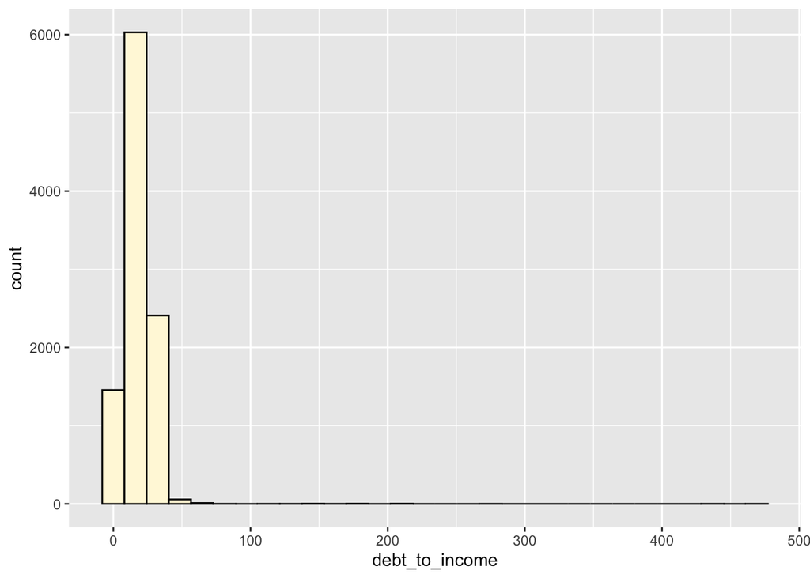

```r
ggplot(df_cleaned, aes(x = debt_to_income)) +
  geom_histogram(fill="cornsilk", color = "black")
```

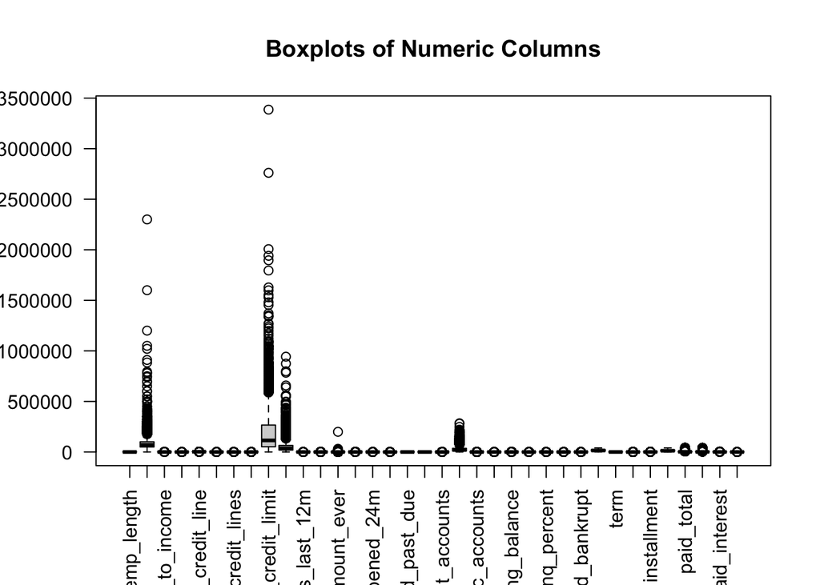

```r
# Replace the NA with mean
replace_debt_income <- mean(na.omit(df_cleaned$debt_to_income)) # mean: 17.43, median: 18.32
df_cleaned$debt_to_income[is.na(df_cleaned$debt_to_income)] <- replace_debt_income
df_cleaned <- na.omit(df_cleaned)
df_cleaned$state <- as.factor(df_cleaned$state)
df_cleaned$application_type <- as.factor(df_cleaned$application_type)
df_cleaned$homeownership <- as.factor(df_cleaned$homeownership)
df_cleaned$loan_purpose <- as.factor(df_cleaned$loan_purpose)
df_cleaned$loan_status <- as.factor(df_cleaned$loan_status)
df_cleaned$disbursement_method <- as.factor(df_cleaned$disbursement_method)
df_cleaned$initial_listing_status <- as.factor(df_cleaned$initial_listing_status)
df_cleaned$verified_income <- as.factor(df_cleaned$verified_income)
df_cleaned$grade <- factor(df_cleaned$grade, levels = c("A", "B", "C", "D", "E", "F", "G"), ordered=TRUE)

# Check outlier
num_cols <- sapply(df_cleaned, is.numeric)
df_num   <- df_cleaned[ , num_cols]
boxplot(df_num,
        main = "Boxplots of Numeric Columns",
        las  = 2,
        col  = "lightgray")
```

```r
outliers_list <- lapply(df_num, function(x) boxplot.stats(x)$out)
```

# Question 1: With different home-ownership is the income have significant different?

### Using One-way ANOVA (failed)

### Reason: The residual didn’t follow the normal distribution

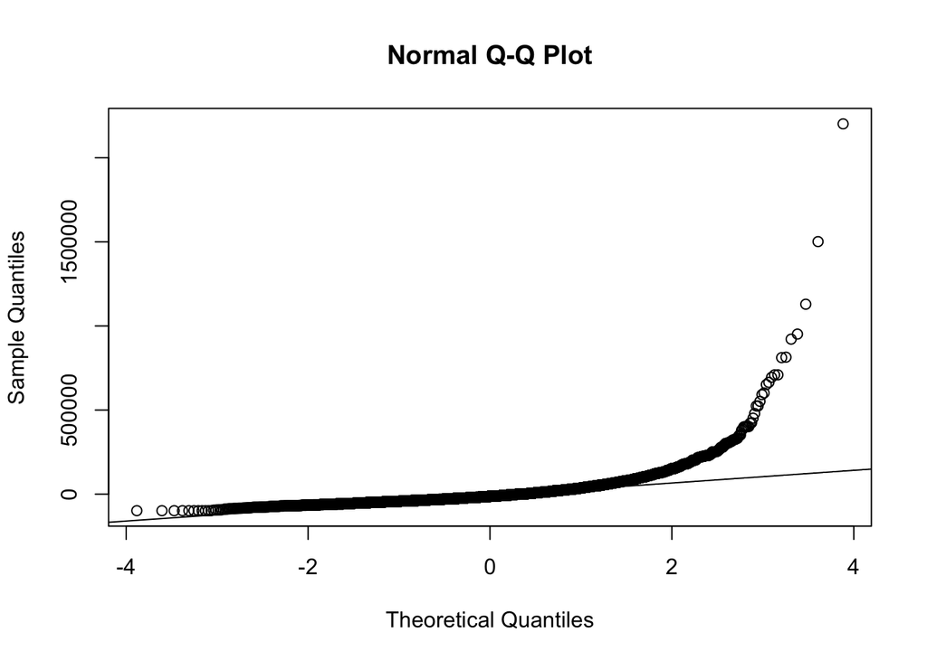

```r
df_cleaned <- df_cleaned[df_cleaned$homeownership != "ANY", ]
df_cleaned <- df_cleaned %>%
  filter(homeownership != "ANY") %>%
  droplevels()
anova_result <- aov(annual_income ~ homeownership, data = df_cleaned)
qqnorm(residuals(anova_result)); qqline(residuals(anova_result))
```

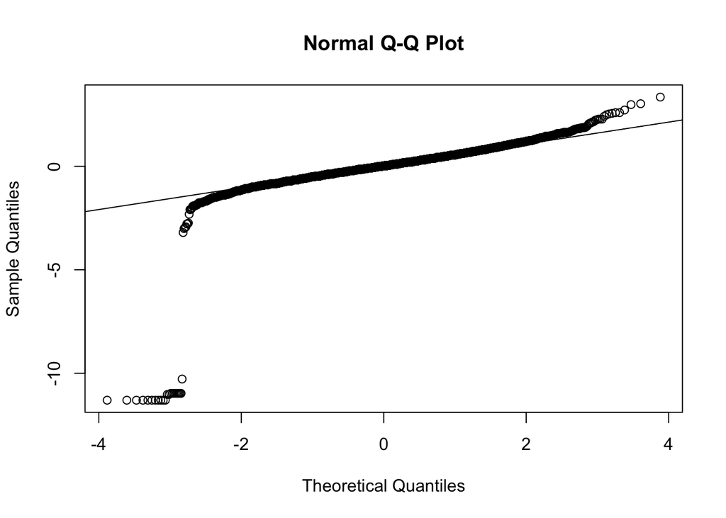

```r
# Try transform the data and try again
anova_trans <- df_cleaned
anova_trans$annual_income_log <- log(anova_trans$annual_income + 1)
anova_trans$annual_income_sqrt <- sqrt(anova_trans$annual_income)
# try again
anova_result <- aov(annual_income_log ~ homeownership, data = anova_trans)
qqnorm(residuals(anova_result)); qqline(residuals(anova_result))
```

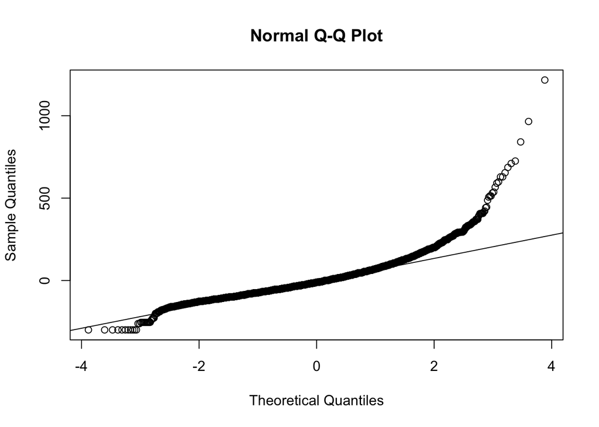

```r
anova_result <- aov(annual_income_sqrt ~ homeownership, data = anova_trans)
qqnorm(residuals(anova_result)); qqline(residuals(anova_result))
```

## Both fail so try nonparametric test

```r
table(df_cleaned$homeownership)
```

```
##
## MORTGAGE      OWN     RENT
##     4619     1325     3738
```

```r
# Since no values for 'ANY' we remove it.
# Using Kruskal–Wallis test (nonparametric): Compares group medians by ranking all data, then testing whether rank-sums differ more than expected by chance.

kw <- kruskal.test(annual_income ~ homeownership, data = df_cleaned)
print(kw)
```

```
##
##  Kruskal-Wallis rank sum test
##
## data:  annual_income by homeownership
## Kruskal-Wallis chi-squared = 735.75, df = 2, p-value < 2.2e-16
```

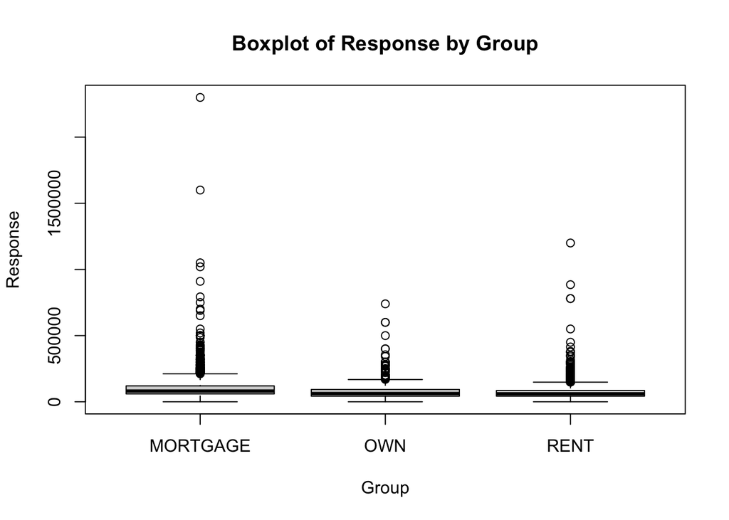

```r
# Assumption:
  # 1. Independence
  # 2. Ordinal or continuous scale
  # 3. Same‐shaped distributions under H0

boxplot(annual_income ~ homeownership, data = df_cleaned,
        main = "Boxplot of Response by Group",
        xlab = "Group", ylab = "Response")
```

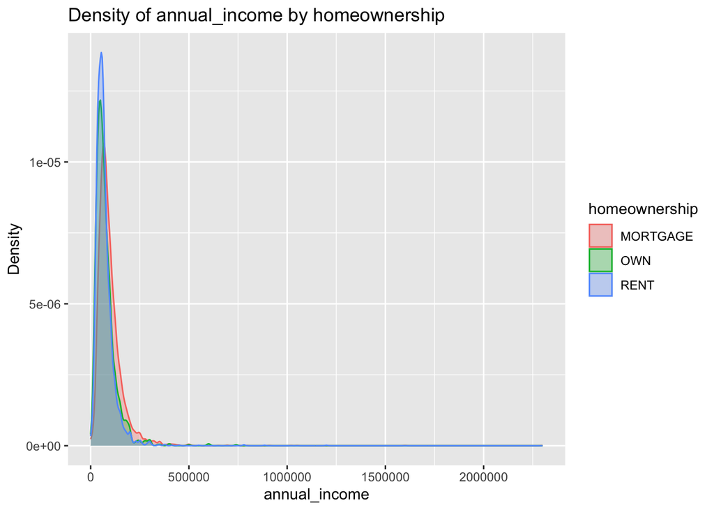

```r
ggplot(df, aes(x = annual_income, color = homeownership, fill = homeownership)) +
  geom_density(alpha = 0.3) +
  labs(title = "Density of annual_income by homeownership",
       x = "annual_income", y = "Density")
```

```r
# By using two plots we can indicate each group have the same-shaped distributions,
# so that differences in ranks reflect shifts in location (medians) only.
```

### Interpretation: Becasue the residuals didn’t follow normalityu so we can’t use the result from ANOVA.

### We choose to use nonparametric Kruskal–Wallis. By using two plots we can said that the group have the same shape of distribution

# Question 2: Predict interest_rate

```r
df_cleaned$num_open_cc_accounts <- NULL
df_cleaned$public_record_bankrupt <- NULL
df_cleaned$term <- NULL
df_cleaned$num_collections_last_12m <- NULL
numeric_cols <- sapply(df_cleaned, is.numeric)
predictors <- names(df_cleaned)[numeric_cols & names(df_cleaned) != "interest_rate"]


X <- as.matrix(df_cleaned[, predictors])
y <- df_cleaned$interest_rate

set.seed(42)
k <- 3

folds <- createFolds(y, k = k, returnTrain = FALSE)


cv_rmse <- numeric(k)
cv_mae <- numeric(k)
cv_r_squared <- numeric(k)


for (i in 1:k) {
  test_indices <- folds[[i]]
  X_train <- X[-test_indices, ]
  y_train <- y[-test_indices]
  X_test <- X[test_indices, ]
  y_test <- y[test_indices]

  cv_model <- cv.glmnet(X_train, y_train, alpha = 1)

  best_lambda <- cv_model$lambda.min

  predictions <- predict(cv_model, s = best_lambda, newx = X_test)

  rmse <- sqrt(mean((predictions - y_test)^2))
  mae <- mean(abs(predictions - y_test))
  ss_total <- sum((y_test - mean(y_test))^2)
  ss_residual <- sum((y_test - predictions)^2)
  r_squared <- 1 - (ss_residual / ss_total)

  cv_rmse[i] <- rmse
  cv_mae[i] <- mae
  cv_r_squared[i] <- r_squared

  cat("Fold", i, "- RMSE:", round(rmse, 4), "MAE:", round(mae, 4), "R²:", round(r_squared, 4), "\n")
}
```

```
## Fold 1 - RMSE: 3.386 MAE: 2.6253 R²: 0.5371
## Fold 2 - RMSE: 3.4428 MAE: 2.6592 R²: 0.5202
## Fold 3 - RMSE: 3.4038 MAE: 2.599 R²: 0.5416
```

```r
avg_rmse <- mean(cv_rmse)
avg_mae <- mean(cv_mae)
avg_r_squared <- mean(cv_r_squared)

cat("\nAverage Cross-Validation Metrics:\n")
```

```
##
## Average Cross-Validation Metrics:
```

```r
cat("RMSE:", round(avg_rmse, 4), "\n")
```

```
## RMSE: 3.4109
```

```r
cat("MAE:", round(avg_mae, 4), "\n")
```

```
## MAE: 2.6278
```

```r
cat("R²:", round(avg_r_squared, 4), "\n")
```

```
## R²: 0.533
```

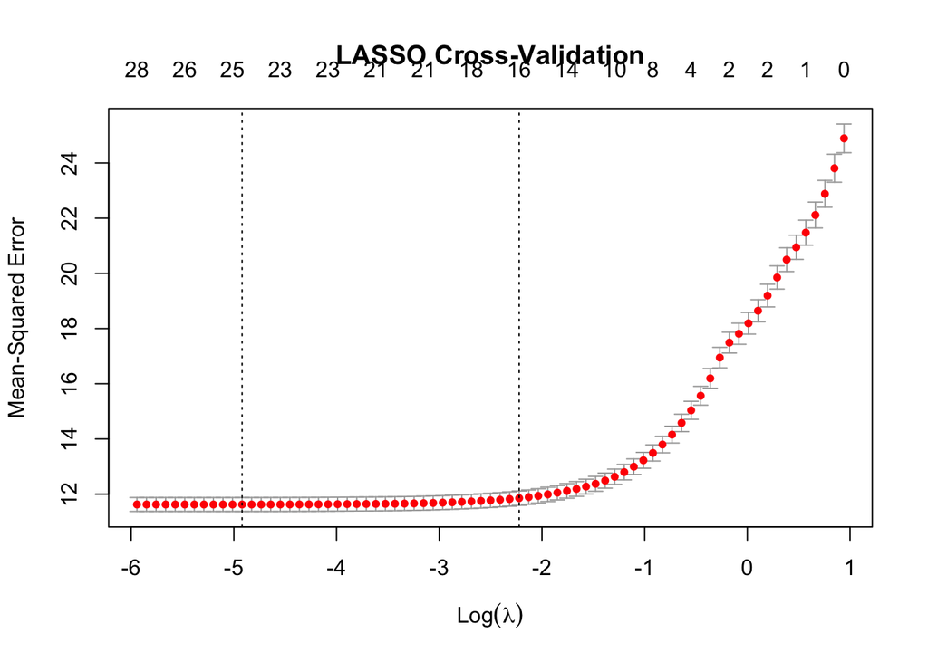

```r
final_cv_model <- cv.glmnet(X, y, alpha = 1)
final_lambda <- final_cv_model$lambda.min

plot(final_cv_model)
title("LASSO Cross-Validation")
```

```r
final_model <- glmnet(X, y, alpha = 1, lambda = final_lambda)

coefs <- coef(final_model)
important_vars <- coefs[which(coefs != 0), ]
cat("\nSelected Variables and Their Coefficients:\n")
```

```
##
## Selected Variables and Their Coefficients:
```

```r
print(important_vars)
```

```
##                  (Intercept)                   emp_length
##                -1.357575e+01                 1.321082e-03
##                annual_income               debt_to_income
##                -2.218373e-06                 2.942233e-02
##                    delinq_2y         earliest_credit_line
##                 3.171113e-01                 1.369868e-02
##           inquiries_last_12m           total_credit_lines
##                 1.139283e-01                -4.934260e-03
##           total_credit_limit        total_credit_utilized
##                -7.352068e-07                 4.375230e-06
## num_historical_failed_to_pay total_collection_amount_ever
##                -2.544843e-03                -9.383703e-06
##          accounts_opened_24m    num_satisfactory_accounts
##                 1.354920e-01                -4.220738e-02
##    num_active_debit_accounts            total_debit_limit
##                 4.515280e-02                -2.872944e-05
##        num_total_cc_accounts      num_cc_carrying_balance
##                -3.593876e-02                 1.401883e-01
##            num_mort_accounts account_never_delinq_percent
##                -1.385511e-01                -2.983888e-02
##                  loan_amount                  installment
##                -1.495801e-04                 9.706780e-04
##                      balance                paid_interest
##                -1.347696e-04                 8.575659e-03
##               paid_late_fees
##                 2.797800e-02
```

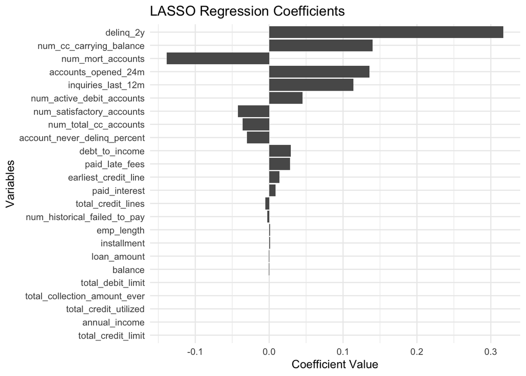

```r
coef_df <- data.frame(
  Variable = row.names(as.matrix(coefs)),
  Coefficient = as.vector(as.matrix(coefs))
) %>% filter(Coefficient != 0)

coef_plot_data <- coef_df[-1, ]

ggplot(coef_plot_data, aes(x = reorder(Variable, abs(Coefficient)), y = Coefficient)) +
  geom_bar(stat = "identity") +
  coord_flip() +
  labs(x = "Variables", y = "Coefficient Value",
       title = "LASSO Regression Coefficients") +
  theme_minimal()
```

# Question 3: Predict Grade by Random Forest

```r
# Split the data
set.seed(42)
rf_data <- df_cleaned
train_index <- sample(seq_len(nrow(rf_data)), size = 0.8 * nrow(rf_data))
train_data <- rf_data[train_index, ]
test_data  <- rf_data[-train_index, ]

rf_model <- randomForest(grade ~ ., data = train_data, importance = TRUE)
importance(rf_model)
```

```
##                                        A           B          C          D
## emp_length                    -0.3018580  2.63547127  0.1724831  2.6780292
## state                         -0.4768494  0.74322419  0.6270011 -1.0091139
## homeownership                  1.6455462  4.37741027  3.0825847  2.6448228
## annual_income                  6.2383871  7.26245410  5.3339835  1.5104429
## verified_income                7.4744535  5.00569530  3.1598506  8.0257544
## debt_to_income                 8.4543900  7.33676035  5.1603171  5.1392133
## delinq_2y                      5.7200781  2.71251534 -0.1194187 -0.2188477
## earliest_credit_line           4.5827822  2.19965684  0.4715767  1.2605802
## inquiries_last_12m             5.0539420  2.11413078 -0.5046804  3.1769454
## total_credit_lines             4.2771614  7.28464510  6.3143893  4.5733285
## open_credit_lines              3.5367323  6.59332070  5.7113881  4.4210121
## total_credit_limit            10.5000549  8.38183659  6.6744643  7.7353115
## total_credit_utilized          5.1294614  6.77644724  6.8958996  8.3842480
## num_historical_failed_to_pay   2.3997116  0.85418235  0.7833942 -1.3353930
## total_collection_amount_ever   7.8745118  2.47403989 -2.1226331 -1.1901346
## current_installment_accounts   1.4976651  6.25712395  2.8619986  0.7645130
## accounts_opened_24m            4.3489271  3.93124882 -0.1381741  2.3317262
## num_satisfactory_accounts      3.1985315  5.59439748  6.3587936  3.5093340
## num_accounts_120d_past_due     0.0000000  0.00000000  0.0000000  0.0000000
## num_accounts_30d_past_due      0.0000000  0.00000000  0.0000000  0.0000000
## num_active_debit_accounts      3.5965387  4.34438164  5.4553174  5.4185987
## total_debit_limit             15.0679386  9.90210997 14.1846354 14.4278239
## num_total_cc_accounts          3.5372694  2.35033585  4.2545542  3.0443804
## num_cc_carrying_balance        5.3599751  2.71417636  3.6410777  3.1020760
## num_mort_accounts              4.4635271  3.37784361  5.2685341  5.8658155
## account_never_delinq_percent  11.0366073 -0.61377071  3.8855129  2.6256699
## tax_liens                     -2.0694789 -0.63080932 -1.1851945  1.5833558
## loan_purpose                   1.0026026  0.89955362  1.9480313  4.2459261
## application_type               1.9040912  2.57450031  0.6923567 -2.6730696
## loan_amount                   13.4792631 18.36611287 18.7010729 15.4784549
## interest_rate                117.3276011 87.12829302 89.7664489 94.2767794
## installment                   14.6840887 17.32871730 19.3124249 16.9637681
## issue_month                    6.2461848  8.53297491  9.9187265  4.1391644
## loan_status                    2.1528930  4.95669608  5.1642052  2.5507908
## initial_listing_status         5.4266671  1.17769850  0.5170690  2.0512079
## disbursement_method            3.4272129  1.30033249  7.0741680 10.3933537
## balance                       14.3327299 18.39133013 20.4201968 16.9281534
## paid_total                    15.0459393 18.90835718 20.9299084 18.7558231
## paid_principal                20.9467526 23.40473639 26.6545161 26.8219448
```

[output cut: 71 more lines]

```
## tax_liens                           -7.197971e-01         3.270306
## loan_purpose                         4.072178e+00        53.342746
## application_type                     1.163056e+00         7.275650
## loan_amount                          2.398234e+01        99.636505
## interest_rate                        1.100564e+02      3190.725015
## installment                          2.297452e+01       142.962955
## issue_month                          1.208462e+01        23.511711
## loan_status                          6.996292e+00        12.989641
## initial_listing_status               5.709032e+00        14.377756
## disbursement_method                  1.024693e+01        17.180547
## balance                              2.330188e+01       124.194991
## paid_total                           2.527440e+01       161.588595
## paid_principal                       3.007122e+01       261.711422
## paid_interest                        3.516132e+01       441.109691
## paid_late_fees                       1.134502e-04         0.899450
```

```r
pred <- predict(rf_model, newdata = test_data[, predictors(rf_model)])
confusionMatrix(pred, test_data$grade)
```

```
## Confusion Matrix and Statistics
##
##           Reference
## Prediction   A   B   C   D   E   F   G
##          A 495   0   0   0   0   0   0
##          B   0 581   0   0   0   0   0
##          C   0   0 510   0   0   0   0
##          D   0   0   0 270  22   2   1
##          E   0   0   0   0  42  10   4
##          F   0   0   0   0   0   0   0
##          G   0   0   0   0   0   0   0
##
## Overall Statistics
##
##                Accuracy : 0.9799
##                  95% CI : (0.9726, 0.9856)
##     No Information Rate : 0.2999
##     P-Value [Acc > NIR] : < 2.2e-16
##
##                   Kappa : 0.9733
##
##  Mcnemar's Test P-Value : NA
##
## Statistics by Class:
##
##                      Class: A Class: B Class: C Class: D Class: E Class: F
## Sensitivity            1.0000   1.0000   1.0000   1.0000  0.65625 0.000000
## Specificity            1.0000   1.0000   1.0000   0.9850  0.99253 1.000000
## Pos Pred Value         1.0000   1.0000   1.0000   0.9153  0.75000      NaN
## Neg Pred Value         1.0000   1.0000   1.0000   1.0000  0.98830 0.993805
## Prevalence             0.2555   0.2999   0.2633   0.1394  0.03304 0.006195
## Detection Rate         0.2555   0.2999   0.2633   0.1394  0.02168 0.000000
## Detection Prevalence   0.2555   0.2999   0.2633   0.1523  0.02891 0.000000
## Balanced Accuracy      1.0000   1.0000   1.0000   0.9925  0.82439 0.500000
##                      Class: G
## Sensitivity          0.000000
## Specificity          1.000000
## Pos Pred Value            NaN
## Neg Pred Value       0.997419
## Prevalence           0.002581
## Detection Rate       0.000000
## Detection Prevalence 0.000000
## Balanced Accuracy    0.500000
```

```r
ctrl <- rfeControl(functions = rfFuncs, method = "cv", number = 5)

# We first test 5, 10, 15, 20. 5 perform best then we narrow the range to 5-9
rfe_res <- rfe(
  x          = train_data[, setdiff(names(train_data), "grade")],
  y          = train_data$grade,
  sizes      = c(5, 6, 7, 8, 9),
  rfeControl = ctrl
)

predictors(rfe_res)
```

```
## [1] "interest_rate"  "paid_interest"  "paid_principal" "paid_total"
## [5] "installment"
```

```r
# re-fit on those
rf_rfe <- randomForest(grade ~ ., data = train_data[, c(predictors(rfe_res), "grade")])

# Evaluate on test data
pred <- predict(rf_rfe, newdata = test_data[, predictors(rfe_res)])
confusionMatrix(pred, test_data$grade)
```

```
## Confusion Matrix and Statistics
##
##           Reference
## Prediction   A   B   C   D   E   F   G
##          A 495   0   0   0   0   0   0
##          B   0 581   0   0   0   0   0
##          C   0   0 510   0   0   0   0
##          D   0   0   0 270   0   0   0
##          E   0   0   0   0  64   1   1
##          F   0   0   0   0   0  10   2
##          G   0   0   0   0   0   1   2
##
## Overall Statistics
##
##                Accuracy : 0.9974
##                  95% CI : (0.994, 0.9992)
##     No Information Rate : 0.2999
##     P-Value [Acc > NIR] : < 2.2e-16
##
##                   Kappa : 0.9966
##
##  Mcnemar's Test P-Value : NA
##
## Statistics by Class:
##
##                      Class: A Class: B Class: C Class: D Class: E Class: F
## Sensitivity            1.0000   1.0000   1.0000   1.0000  1.00000 0.833333
## Specificity            1.0000   1.0000   1.0000   1.0000  0.99893 0.998961
## Pos Pred Value         1.0000   1.0000   1.0000   1.0000  0.96970 0.833333
## Neg Pred Value         1.0000   1.0000   1.0000   1.0000  1.00000 0.998961
## Prevalence             0.2555   0.2999   0.2633   0.1394  0.03304 0.006195
## Detection Rate         0.2555   0.2999   0.2633   0.1394  0.03304 0.005163
## Detection Prevalence   0.2555   0.2999   0.2633   0.1394  0.03407 0.006195
## Balanced Accuracy      1.0000   1.0000   1.0000   1.0000  0.99947 0.916147
##                      Class: G
## Sensitivity          0.400000
## Specificity          0.999482
## Pos Pred Value       0.666667
## Neg Pred Value       0.998449
## Prevalence           0.002581
## Detection Rate       0.001033
## Detection Prevalence 0.001549
## Balanced Accuracy    0.699741
```